# Lab 4 Checkpoint 4

Leticia Wanderley

8/6/2017

## Lab 4 Checkpoint 4

### p-valor

O p-valor é a probabilidade de encontrar resultados iguais ou maiores que os do experimento quando a hipótese nula é verdadeira. Ou seja, em uma situação na qual os parâmetros do experimento (hipótese alternativa) não são levados em conta encontrar um resultado similarao da hipótese alternativa. Trazendo para o caso particular desta análise é encontrar diferenças da utilização de linguagens entre 2016 e 2017 similares no conjunto de dados original (com cada leitura de usuários correspondendo a uma data) e em conjunto de dados embaralhado. Os dados embaralhados representam a probabilidade das diferenças encontradas nos dados originais serem inerentes às distribuição do conjunto e não resultantes da variação de uso em diferentes anos.

[Análise feita utilizando ICs](https://leticiawanderley.github.io/ad/lab4/lab4_checkpoint3.html)

#### A diferença média de usuários de Go entre 2016 e 2017 é significativa? A quantidade de usuários aumentou?

Para responder essa pergunta o conjunto de dados será filtrado para conter apenas dados referentes a linguagem Go.

```r
go <- commits %>%
  filter(file_extension=="go")
```

A média de usuários commitando em 2016 e 2017 pode ser vista na tabela abaixo.

```r
go.mean.years = go %>%
  group_by(the_year) %>%
  summarise(mean=mean(users))
go.mean.years
```

```
## # A tibble: 2 x 2
##   the_year     mean
##      <int>    <dbl>
## 1     2016 890.1304
## 2     2017 886.7417
```

E a diferença entre as médias é de aproximadamente 3.39 usuários.

```r
diff.go.mean.years = diff(go.mean.years$mean)
diff.go.mean.years
```

```
## [1] -3.388768
```

Para estimar o p-valor se vai fazer uma reamostragem das quantidades de usuários embaralhando os anos aos quais as quantidades fazem referência. Isso cria um ambiente no qual a distribuição dos valores é mantida sem levar em conta a hipótese alternativa, de que a diferença entre os anos é significativa.

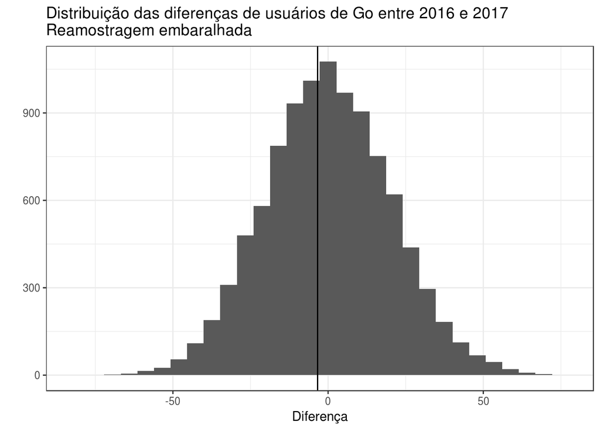

```r
set.seed(1)
diffs.go = replicate(10000, {
  means = go %>%
    mutate(id_shuffled = sample(the_year)) %>%
    group_by(id_shuffled) %>%
    summarise(mean = mean(users))
  dezesseis = means %>%
    filter(id_shuffled == 2016)
  dezessete = means %>%
    filter(id_shuffled == 2017)
  return(dezesseis$mean - dezessete$mean)
})

tibble(diff = diffs.go) %>%
  ggplot(aes(x = diff)) +
  geom_histogram(bins = 30) +
  geom_vline(xintercept = diff.go.mean.years) +
  labs(title="Distribuição das diferenças de usuários de Go entre 2016 e 2017\nReamostragem embaralhada",
       x="Diferença", y="")
```

No gráfico acima se vê a distribuição das diferenças das médias encontradas na reamostragem aleatória embaralhada. A linha vertical representa a diferença média dos dados originais. Se pode observar que a linha está quase no centro da distribuição, um indicativo de que a hipótese nula é verdadeira e que a diferença de usuários de Go entre 2016 e 2017 não é significativa. A probabilidade de se encontrar um valor igual ou maior que o encontrado nos dados originais é alta.

O p-valor encontrado é 0.8654, o que significa que em aproximadamente 86% dos casos da reamostragem o valor absoluto da diferença foi maior ou igual ao valor encontrado nos dados originais. Com esse resultado não é possível rejeitar a hipótese nula, não se confirma que a diferença entre os usuários de Go entre 2016 e 2017 encontrada no dados originais é significativa.

```r
sum(abs(diffs.go) >= abs(diff.go.mean.years)) / length(diffs.go)
```

```
## [1] 0.8654
```

### Repetindo a mesma análise com para a linguagem XML

XML é uma linguagem mais obsoleta, será que a quantidade de usuários diminuiu entre 2016 e 2017, a diferença é significativa?

Filtrando o conjunto de dados para conter apenas dados referentes a XML.

```r
xml <- commits %>%
  filter(file_extension== "xml")
```

As médias de usuários em 2016 e 2017 pode ser observada na tabela abaixo.

```r
xml.mean.years = xml %>%
  group_by(the_year) %>%
  summarise(mean=mean(users))
xml.mean.years
```

```
## # A tibble: 2 x 2
##   the_year     mean
##      <int>    <dbl>
## 1     2016 2589.079
## 2     2017 2347.015
```

A diferença entre as médias dos dois anos é aproximadamente de 242 usuários.

```r
diff.xml.mean.years = diff(xml.mean.years$mean)
diff.xml.mean.years
```

```
## [1] -242.0639
```

Realizando a reamostragem embaralhada se certifica que o conjunto de dados resultante equivale a hipótese nula. O gráfico mostra a distribuição das diferenças de usuários entre os anos, dos dados embaralhados. A linha vertical representa a diferença encontrada no conjunto de dados original.

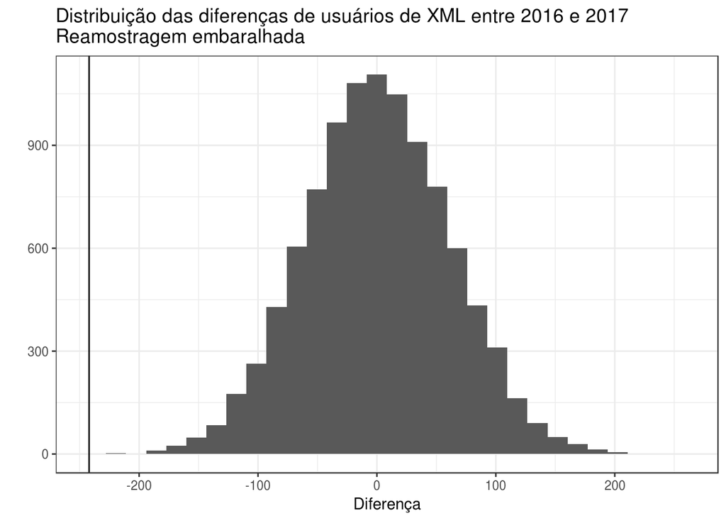

```r
set.seed(1)
diffs.xml = replicate(10000, {
  means = xml %>%
    mutate(id_shuffled = sample(the_year)) %>%
    group_by(id_shuffled) %>%
    summarise(mean = mean(users))
  dezesseis = means %>%
    filter(id_shuffled == 2016)
  dezessete = means %>%
    filter(id_shuffled == 2017)
  return(dezesseis$mean - dezessete$mean)
})

tibble(diff = diffs.xml) %>%
  ggplot(aes(x = diff)) +
  geom_histogram(bins = 30) +
  geom_vline(xintercept = diff.xml.mean.years) +
  labs(title="Distribuição das diferenças de usuários de XML entre 2016 e 2017\nReamostragem embaralhada",
       x="Diferença", y="")
```

Como se pode ver no gráfico a diferença encontrada nos dados originais está muito distante da distribuição dos dados embaralhados o que corrobora com a hipótese alternativa e permite rejeitar a hipótese nula.

O p-valor encontrado é de 0.0001. Isso quer dizer que em apenas 0.01% dos casos o valor absoluto de diferença encontrado nos dados embaralhados foi maior ou igual ao valor encontrado nos dados originais.

```r
sum(abs(diffs.xml) >= abs(diff.xml.mean.years)) / length(diffs.xml)
```

```
## [1] 1e-04
```

### Comparando ICs x Teste de hipótese

> Os resultados das análises utilizando intervalos de confiança e testes de hipótese concordam.

Ao analisar o conjunto de dados referentes a **Go** o intervalo de confiança das diferenças entre 2016 e 2017 foi inconclusivo, é composto por valores maiores que 1 e menores que 1, e inclui o valor 0. Esses resultados são indicativos de que não existe diferença significativa entre o número de usuários nos anos analisados. Utilizando testes de hipótese foi possível perceber que a diferença média entre os anos no conjunto de dados não é significativa, valores maiores ou iguais a essa diferença foram encontrados em mais de 80% dos dados embaralhados. O valor de diferença encontrado é comum no cojunto de dados e não tem significância.

> Com o uso de intervalos de confiança é possível estimar, até certo ponto, o valor da diferença entre os anos. Com testes de hipóteses se pode inferir sobre a significância dos resultados obtidos em uma análise.

Analisando o conjunto de dados referentes a **XML** o intervalo de confiança resultante da reamostragem das diferenças de quantidade de usuários ativos em entre 2016 e 2017 estava contido, completamente, dentro do conjunto dos reais menores que 1. Isso significa que a quantidade de usuários em 2017 foi sempre menor que a quantidade de usuários em 2016. O resultado do teste de hipótese corrobora com o intervalo de confiança. A diferença média entre os anos foi de -242 aproximadamente, e a probabilidade de, dentro do conjunto de dados embaralhados, encontrar valores absolutos maiores ou iguais a essa valor foi de 0.01%. O que reafirma a significância do valor encontrado, a diferença entre os anos é significativa.